# **Space X Falcon 9 First Stage Landing Prediction**

## Introduction

**Capstone Project for 'IBM Professional Certificate in Data Science with Python'**  
In this project, I constructed a machine learning model that can predict whether Falcon 9 will land successfuly in the first stage. [Falcon 9](https://www.spacex.com/vehicles/falcon-9/) is classified as a medium-lift partially reusable rocket, used to launch hefty communications and satellites into Earth orbit or ferry austronaouts to and from the International Space Station. As of April 2022, SpaceX offers Falcon 9 rocket launches for [USD 62 million](https://www.nbcnews.com/science/space/space-launch-costs-growing-business-industry-rcna23488), which means around USD 1,200 per pound of payload. For comparison, per pound cost of SpaceX competitors is 3 to 5 times more expensive, whereas traditional NASA space shuttles, retired in 2011, cost an average of [USD 1.6 billion](https://aerospace.csis.org/data/space-launch-to-low-earth-orbit-how-much-does-it-cost/) per flight. SpaceX is able to provide rocket launches for unprecedented low prices, because it can reuse the first stage, which significantly reduces the demand for new cores. Therefore, determining whether the first stage will land, helps to estimate the cost of a launch. This information can also be used if another company wants to bid against SpaceX for a rocket launch. For this project, I use API requests to pull data from `https://api.spacexdata.com/v4` and webscraping to collect data from Wikipedia.

[figure not shown]

# Construct the Predictive Model

In this notebook, I create a machine learning pipeline to predict if the first stage will land given the data from the preceding labs.

> Objectives:
- Define the outcome variable
- Standardize the data
- Split the dataset into training data and test data
- Test several different models: SVM, Classification Trees and Logistic Regression
- Identify the best-performing model

## Import Libraries and Define Auxiliary Functions

We will import the following libraries for the lab

```python
# Pandas is a software library written for the Python programming language for data manipulation and analysis.
import pandas as pd
# NumPy is a library for the Python programming language, adding support for large, multi-dimensional arrays and matrices, along with a large collection of high-level mathematical functions to operate on these arrays
import numpy as np
# Matplotlib is a plotting library for python and pyplot gives us a MatLab like plotting framework. We will use this in our plotter function to plot data.
import matplotlib.pyplot as plt
#Seaborn is a Python data visualization library based on matplotlib. It provides a high-level interface for drawing attractive and informative statistical graphics
import seaborn as sns

# Preprocessing allows us to standarsize our data
from sklearn import preprocessing
# Allows us to split our data into training and testing data
from sklearn.model_selection import train_test_split
# Allows us to test parameters of classification algorithms and find the best one
from sklearn.model_selection import GridSearchCV
# Logistic Regression classification algorithm
from sklearn.linear_model import LogisticRegression
# Support Vector Machine classification algorithm
from sklearn.svm import SVC
# Decision Tree classification algorithm
from sklearn.tree import DecisionTreeClassifier
# K Nearest Neighbors classification algorithm
from sklearn.neighbors import KNeighborsClassifier
```

The function I will use to plot the confusion matrix.

```python
def plot_confusion_matrix(y,y_predict):
    "this function plots the confusion matrix"
    from sklearn.metrics import confusion_matrix

    cm = confusion_matrix(y, y_predict)
    ax= plt.subplot()
    sns.heatmap(cm, annot=True, ax = ax); #annot=True to annotate cells
    ax.set_xlabel('Predicted labels')
    ax.set_ylabel('True labels')
    ax.set_title('Confusion Matrix');
    ax.xaxis.set_ticklabels(['did not land', 'land']); ax.yaxis.set_ticklabels(['did not land', 'landed'])
    plt.show()
```

Load the data

```python
# import csv file
df2 = pd.read_csv('dataset_part_2.csv')

# import csv file
X = pd.read_csv('dataset_part_3.csv')
```

```python
df2.head()
```

|  | FlightNumber | Date | BoosterVersion | PayloadMass | Orbit | LaunchSite | Outcome | Flights | GridFins | Reused | Legs | LandingPad | Block | ReusedCount | Serial | Longitude | Latitude | Class |
| --- | --- | --- | --- | --- | --- | --- | --- | --- | --- | --- | --- | --- | --- | --- | --- | --- | --- | --- |
| 0 | 1 | 2010-06-04 | Falcon 9 | 6123.547647 | LEO | CCSFS SLC 40 | None None | 1 | False | False | False | NaN | 1.0 | 0 | B0003 | -80.577366 | 28.561857 | 0 |
| 1 | 2 | 2012-05-22 | Falcon 9 | 525.000000 | LEO | CCSFS SLC 40 | None None | 1 | False | False | False | NaN | 1.0 | 0 | B0005 | -80.577366 | 28.561857 | 0 |
| 2 | 3 | 2013-03-01 | Falcon 9 | 677.000000 | ISS | CCSFS SLC 40 | None None | 1 | False | False | False | NaN | 1.0 | 0 | B0007 | -80.577366 | 28.561857 | 0 |
| 3 | 4 | 2013-09-29 | Falcon 9 | 500.000000 | PO | VAFB SLC 4E | False Ocean | 1 | False | False | False | NaN | 1.0 | 0 | B1003 | -120.610829 | 34.632093 | 0 |
| 4 | 5 | 2013-12-03 | Falcon 9 | 3170.000000 | GTO | CCSFS SLC 40 | None None | 1 | False | False | False | NaN | 1.0 | 0 | B1004 | -80.577366 | 28.561857 | 0 |

```python
# data tpes
df2.dtypes
```

```
FlightNumber        int64
Date               object
BoosterVersion     object
PayloadMass       float64
Orbit              object
LaunchSite         object
Outcome            object
Flights             int64
GridFins             bool
Reused               bool
Legs                 bool
LandingPad         object
Block             float64
ReusedCount         int64
Serial             object
Longitude         float64
Latitude          float64
Class               int64
dtype: object
```

```python
# data tpes
X.dtypes
```

```
FlightNumber     float64
PayloadMass      float64
Flights          float64
Block            float64
ReusedCount      float64
                  ...
GridFins_True    float64
Reused_False     float64
Reused_True      float64
Legs_False       float64
Legs_True        float64
Length: 83, dtype: object
```

### Define the predicter and outcome variables

Create a NumPy array from the column `Class` in `data`, by applying the method `to_numpy()` then assign it to the variable `Y`,make sure the output is a Pandas series (only one bracket df['name of column']).

```python
# Assuming 'data' is your DataFrame and 'Class' is the column name
Y = df2['Class'].to_numpy()

# Display the first few elements of the array to confirm
print(Y[:25])
```

```
[0 0 0 0 0 0 1 1 0 0 0 0 1 0 0 0 1 0 0 1 1 1 1 1 0]
```

Standardize the data in `X` then reassign it to the variable `X` using the transform provided below.

```python
# Initialize the StandardScaler
transform = preprocessing.StandardScaler()
```

```python
# Ensure X is a DataFrame at this point
# If X is not a DataFrame here, you need to check the previous steps where X is defined or modified

# Store the original column names
original_columns = X.columns

# Initialize the StandardScaler
transform = preprocessing.StandardScaler()

# Fit the scaler to the data and transform it
X = transform.fit_transform(X)

# Convert the transformed data back into a DataFrame using the original column names
X = pd.DataFrame(X, columns=original_columns)
```

### Split the training and test data

We split the data into training and testing data using the function `train_test_split`. The training data is divided into validation data, a second set used for training data; then the models are trained and hyperparameters are selected using the function `GridSearchCV`.

Use the function train_test_split to split the data X and Y into training and test data. Set the parameter test_size to 0.2 and random_state to 2. The training data and test data should be assigned to the following labels.

`X_train, X_test, Y_train, Y_test`

Now X_train and Y_train are your training features and labels X_test and Y_test are your testing features and labels

```python
# Split the data into training and testing sets
X_train, X_test, Y_train, Y_test = train_test_split(X, Y, test_size=0.2, random_state=2)
```

We can see we only have 18 test samples.

```python
Y_test.shape
```

```
(18,)
```

### Logistic Regression Model

Create a logistic regression object then create a GridSearchCV object `logreg_cv` with cv = 10. Fit the object to find the best parameters from the dictionary `parameters`.

```python
parameters ={'C':[0.01,0.1,1],
             'penalty':['l2'],
             'solver':['lbfgs']}

# Create a Logistic Regression classifier object
logreg = LogisticRegression()

# Create a GridSearchCV object
logreg_cv = GridSearchCV(logreg, parameters, cv=10)

# Fit the GridSearchCV object to the training data
logreg_cv.fit(X_train, Y_train)
```

```
GridSearchCV(cv=10, estimator=LogisticRegression(),
             param_grid={'C': [0.01, 0.1, 1], 'penalty': ['l2'],
                         'solver': ['lbfgs']})
```

We output the `GridSearchCV` object for logistic regression. We display the best parameters using the data attribute `best_params_` and the accuracy on the validation data using the data attribute `best_score_`.

```python
print("tuned hpyerparameters :(best parameters) ",logreg_cv.best_params_)
print("accuracy :",logreg_cv.best_score_)
```

```
tuned hpyerparameters :(best parameters)  {'C': 0.01, 'penalty': 'l2', 'solver': 'lbfgs'}
accuracy : 0.8464285714285713
```

Calculate the accuracy on the test data using the method `score`:

```python
# Calculate the accuracy on the test data using the method score:
print('Test data accuracy score:', logreg_cv.score(X_test, Y_test))
```

```
Test data accuracy score: 0.8333333333333334
```

Lets look at the confusion matrix:

```python
# Confusion Matrix
yhat=logreg_cv.predict(X_test)
plot_confusion_matrix(Y_test,yhat)
```

[output not shown]

```python
# Get the logistic regression model with the best parameters
best_logreg_model = logreg_cv.best_estimator_

# Get the coefficients from the model
coefficients = best_logreg_model.coef_[0]

# Match coefficients to the feature names
feature_names = X.columns
feature_importance = pd.DataFrame(coefficients, index=feature_names, columns=["Coefficient"]).sort_values(by="Coefficient", ascending=False)

print(feature_importance)
```

```
                                     Coefficient
Legs_True                               0.121528
GridFins_True                           0.109527
ReusedCount                             0.075330
Block                                   0.054311
LandingPad_5e9e3032383ecb267a34e7c7     0.053606
...                                          ...
Serial_B1028                           -0.054075
Serial_B1017                           -0.055206
Serial_B1050                           -0.059022
GridFins_False                         -0.109527
Legs_False                             -0.121528

[83 rows x 1 columns]
```

### Support Vector Machine (SVM) model

Create a support vector machine object then create a `GridSearchCV` object `svm_cv` with cv - 10. Fit the object to find the best parameters from the dictionary `parameters`.

```python
parameters = {'kernel':('linear', 'rbf','poly','rbf', 'sigmoid'),
              'C': np.logspace(-3, 3, 5),
              'gamma':np.logspace(-3, 3, 5)}
svm = SVC()
```

```python
# Create a GridSearchCV object
svm_cv = GridSearchCV(svm, parameters, cv=10)

# Fit the GridSearchCV object to the training data
svm_cv.fit(X_train, Y_train)
```

[output not shown]

```python
# Print the best parameters found by GridSearchCV
print("tuned hpyerparameters :(best parameters) ",svm_cv.best_params_)

# Training data accuracy
print("accuracy :",svm_cv.best_score_)
```

```
tuned hpyerparameters :(best parameters)  {'C': 0.03162277660168379, 'gamma': 0.001, 'kernel': 'linear'}
accuracy : 0.8357142857142856
```

Calculate the accuracy on the test data using the method `score`:

```python
# Calculate the accuracy on the test data:
print('Test data accuracy score:', svm_cv.score(X_test, Y_test))
```

```
Test data accuracy score: 0.8333333333333334
```

We can plot the confusion matrix

```python
yhat=svm_cv.predict(X_test)
plot_confusion_matrix(Y_test,yhat)
```

[output not shown]

### Decision Tree Classifier

Create a decision tree classifier object then create a `GridSearchCV` object `tree_cv` with cv = 10. Fit the object to find the best parameters from the dictionary `parameters`.

```python
parameters = {
    'criterion': ['gini', 'entropy'],
    'splitter': ['best', 'random'],
    'max_depth': [2*n for n in range(1,10)],
    'max_features': ['sqrt', 'log2', None],  # Removed 'auto'
    'min_samples_leaf': [1, 2, 4],
    'min_samples_split': [2, 5, 10]
}

tree = DecisionTreeClassifier()

# Create a GridSearchCV object
tree_cv = GridSearchCV(tree, parameters, cv=10)

# Fit the GridSearchCV object to the training data
tree_cv.fit(X_train, Y_train)

# Print the best parameters found by GridSearchCV
print("Best parameters found by GridSearchCV:", tree_cv.best_params_)
```

```
Best parameters found by GridSearchCV: {'criterion': 'gini', 'max_depth': 10, 'max_features': None, 'min_samples_leaf': 4, 'min_samples_split': 2, 'splitter': 'best'}
```

```python
print("accuracy :",tree_cv.best_score_)
```

```
accuracy : 0.8857142857142858
```

Calculate the accuracy of tree_cv on the test data using the method `score`:

```python
# Create a DecisionTreeClassifier with the best parameters
optimal_tree = DecisionTreeClassifier(
    criterion='gini',
    max_depth=10,
    max_features=None,
    min_samples_leaf=4,
    min_samples_split=2,
    splitter='best'
)

# Fit the model to the training data
optimal_tree.fit(X_train, Y_train)
print("Training accuracy:", optimal_tree.score(X_train, Y_train))

# Evaluate the model's performance on the test data
test_accuracy = optimal_tree.score(X_test, Y_test)
print("Test accuracy with optimal parameters:", test_accuracy)
```

```
Training accuracy: 0.9027777777777778
Test accuracy with optimal parameters: 0.7777777777777778
```

We can plot the confusion matrix

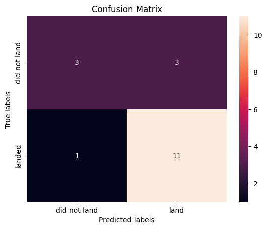

```python
yhat = tree_cv.predict(X_test)
plot_confusion_matrix(Y_test,yhat)
```

### K-Nearest Neighbors (KNN) Classifier

Create a k nearest neighbors object then create a `GridSearchCV` object `knn_cv` with cv = 10. Fit the object to find the best parameters from the dictionary `parameters`.

```python
parameters = {'n_neighbors': [1, 2, 3, 4, 5, 6, 7, 8, 9, 10],
              'algorithm': ['auto', 'ball_tree', 'kd_tree', 'brute'],
              'p': [1,2]}

KNN = KNeighborsClassifier()

# Create a GridSearchCV object
knn_cv = GridSearchCV(KNN, parameters, cv=10)

# Fit the GridSearchCV object to the training data
knn_cv.fit(X_train, Y_train)

# Print the best parameters found by GridSearchCV
print("Best parameters found by GridSearchCV:", knn_cv.best_params_)
```

```
Best parameters found by GridSearchCV: {'algorithm': 'auto', 'n_neighbors': 10, 'p': 1}
```

```python
print("tuned hpyerparameters :(best parameters) ",knn_cv.best_params_)
print("accuracy :",knn_cv.best_score_)
```

```
tuned hpyerparameters :(best parameters)  {'algorithm': 'auto', 'n_neighbors': 10, 'p': 1}
accuracy : 0.8482142857142858
```

Calculate the accuracy of knn_cv on the test data using the method `score`:

```python
# Calculate the accuracy on the test data
test_accuracy_knn = knn_cv.score(X_test, Y_test)

print("KNN accuracy on test data:", test_accuracy_knn)
```

```
KNN accuracy on test data: 0.8333333333333334
```

We can plot the confusion matrix

```python
yhat = knn_cv.predict(X_test)
plot_confusion_matrix(Y_test,yhat)
```

[output not shown]

### Conclusion

We notice all our models, perform similarly on the test data, absent the decision tree model. All of them achieve around 83% accuracy on the test data. With all things considred, it is best to choose the regression model, because of its simplicity. Overall, we had 90 flight registrations in our data set. With more flight recordings down the road we can further increase/improve the accuracy of our model.